# sklearn-random-forest2

## Ensemble Learning: The Use of the Random Forest Algorithm to Perform Human Activity Recognition From Wearable Accelerometer Data.

We will implement a series of random forests and train the models to discern one of six potential human activities being performed, based solely on the accelerometer data of our dataset. Each training iteration of the random forest will have slightly different hyperparameter tunings, and we will then determine the best model from the resulting accuracy metrics.

The random forest algorithm is robust against overfitting. Although they leverage the ability of decision trees to fit training data very well, the use of a random subset of training features produces a set of decision trees that will be distinctly random from one another. This will ensure that the trees are not highly correlated, and the use of "bagging" (bootstrap aggregation) as part of the random forest algorithm ensures that the high variance of the standard decision tree algo is also mitigated.

The Human Activity Recognition database was built from the recordings of 30 study participants performing activities of daily living (ADL) while carrying a waist-mounted smartphone with embedded inertial sensors. The objective is to classify activities into one of the six activities performed:

- WALKING
- WALKING UPSTAIRS
- WALKING DOWNSTAIRS
- SITTING
- STANDING
- LAYING

### Summary

With 561 feature vectors, each comprised of sensor signals (accelerometer and gyroscope), we have been able to use the data to discern the difference between 6 classes of human activity. We began with a dimensionality reduction in order to visualize the 561-dimensional data space, reduced down to 3 principal components containing the majority of the original variance, plotted onto a 3-dimensional set of axes. The datapoints were found to clearly express 2 major clusters of data, with each cluster containing the 3 subgroups within those clusters of data.

A series of random forest classifiers were fitted and analyzed for their respective predictive power. The criteria of Gini and Entropy were tried, as well as the maximum depth of the trees, and the minimum impurity decrease to split nodes. A random forest of 59 sub-trees was selected as the best performing model of the set. A max depth of 20 and a minimum impurity decrease of 0.0 were found the be ideal.

There was a discernable difficulty in classifying the difference between walking downstairs, walking upstairs, and general walking. The observed activities of walking downstairs and especially walking upstairs were being misclassified as walking, and walking downstairs was also misclassified as walking upstairs. Even so, the rest of the human activities were relatively easily classified with a high measure of recall and precision. The classification report shows relatively good performance, with an average recall of 0.94, and an average f1-score of 0.94. The worst f1-score corresponds to class 4 (walking downstairs), with a score of 0.90.

[output not shown]

### Description of the Experiment

The experiments have been carried out with a group of 30 volunteers within an age bracket of 19-48 years. Each person performed six activities (WALKING, WALKING UPSTAIRS, WALKING DOWNSTAIRS, SITTING, STANDING, LAYING) wearing a smartphone (Samsung Galaxy S II) on the waist. Using its embedded accelerometer and gyroscope, we captured 3-axial linear acceleration and 3-axial angular velocity at a constant rate of 50Hz. The experiments have been video-recorded to label the data manually. The obtained dataset has been randomly partitioned into two sets, where 70% of the volunteers was selected for generating the training data and 30% the test data.

The sensor signals (accelerometer and gyroscope) were pre-processed by applying noise filters and then sampled in fixed-width sliding windows of 2.56 sec and 50% overlap (128 readings/window). The sensor acceleration signal, which has gravitational and body motion components, was separated using a Butterworth low-pass filter into body acceleration and gravity. The gravitational force is assumed to have only low frequency components, therefore a filter with 0.3 Hz cutoff frequency was used. From each window, a vector of features was obtained by calculating variables from the time and frequency domain.

### Feature Information

- Triaxial acceleration from the accelerometer (total acceleration) and the estimated body acceleration.
- Triaxial Angular velocity from the gyroscope.
- A 561-feature vector with time and frequency domain variables.
- The activity label.
- An identifier of the subject who carried out the experiment.

### Citation

Davide Anguita, Alessandro Ghio, Luca Oneto, Xavier Parra and Jorge L. Reyes-Ortiz. A Public Domain Dataset for Human Activity Recognition Using Smartphones. *21st European Symposium on Artificial Neural Networks, Computational Intelligence and Machine Learning, ESANN* 2013. Bruges, Belgium 24-26 April 2013.

```python
import numpy as np
import pandas as pd
from sklearn.ensemble import RandomForestClassifier
import matplotlib.pyplot as plt
% matplotlib inline
from sklearn.metrics import accuracy_score
from sklearn.metrics import confusion_matrix, classification_report
```

### Import the Data

```python
har_train_df = pd.read_csv('human_activity/train.csv')
har_test_df = pd.read_csv('human_activity/test.csv')
```

```python
har_train_df.head()
```

|  | tBodyAcc-mean()-X | tBodyAcc-mean()-Y | tBodyAcc-mean()-Z | tBodyAcc-std()-X | tBodyAcc-std()-Y | tBodyAcc-std()-Z | tBodyAcc-mad()-X | tBodyAcc-mad()-Y | tBodyAcc-mad()-Z | tBodyAcc-max()-X | ... | fBodyBodyGyroJerkMag-kurtosis() | angle(tBodyAccMean,gravity) | angle(tBodyAccJerkMean),gravityMean) | angle(tBodyGyroMean,gravityMean) | angle(tBodyGyroJerkMean,gravityMean) | angle(X,gravityMean) | angle(Y,gravityMean) | angle(Z,gravityMean) | subject | Activity |
| --- | --- | --- | --- | --- | --- | --- | --- | --- | --- | --- | --- | --- | --- | --- | --- | --- | --- | --- | --- | --- | --- |
| 0 | 0.288585 | -0.020294 | -0.132905 | -0.995279 | -0.983111 | -0.913526 | -0.995112 | -0.983185 | -0.923527 | -0.934724 | ... | -0.710304 | -0.112754 | 0.030400 | -0.464761 | -0.018446 | -0.841247 | 0.179941 | -0.058627 | 1 | STANDING |
| 1 | 0.278419 | -0.016411 | -0.123520 | -0.998245 | -0.975300 | -0.960322 | -0.998807 | -0.974914 | -0.957686 | -0.943068 | ... | -0.861499 | 0.053477 | -0.007435 | -0.732626 | 0.703511 | -0.844788 | 0.180289 | -0.054317 | 1 | STANDING |
| 2 | 0.279653 | -0.019467 | -0.113462 | -0.995380 | -0.967187 | -0.978944 | -0.996520 | -0.963668 | -0.977469 | -0.938692 | ... | -0.760104 | -0.118559 | 0.177899 | 0.100699 | 0.808529 | -0.848933 | 0.180637 | -0.049118 | 1 | STANDING |
| 3 | 0.279174 | -0.026201 | -0.123283 | -0.996091 | -0.983403 | -0.990675 | -0.997099 | -0.982750 | -0.989302 | -0.938692 | ... | -0.482845 | -0.036788 | -0.012892 | 0.640011 | -0.485366 | -0.848649 | 0.181935 | -0.047663 | 1 | STANDING |
| 4 | 0.276629 | -0.016570 | -0.115362 | -0.998139 | -0.980817 | -0.990482 | -0.998321 | -0.979672 | -0.990441 | -0.942469 | ... | -0.699205 | 0.123320 | 0.122542 | 0.693578 | -0.615971 | -0.847865 | 0.185151 | -0.043892 | 1 | STANDING |

5 rows × 563 columns

```python
har_test_df.head()
```

|  | tBodyAcc-mean()-X | tBodyAcc-mean()-Y | tBodyAcc-mean()-Z | tBodyAcc-std()-X | tBodyAcc-std()-Y | tBodyAcc-std()-Z | tBodyAcc-mad()-X | tBodyAcc-mad()-Y | tBodyAcc-mad()-Z | tBodyAcc-max()-X | ... | fBodyBodyGyroJerkMag-kurtosis() | angle(tBodyAccMean,gravity) | angle(tBodyAccJerkMean),gravityMean) | angle(tBodyGyroMean,gravityMean) | angle(tBodyGyroJerkMean,gravityMean) | angle(X,gravityMean) | angle(Y,gravityMean) | angle(Z,gravityMean) | subject | Activity |
| --- | --- | --- | --- | --- | --- | --- | --- | --- | --- | --- | --- | --- | --- | --- | --- | --- | --- | --- | --- | --- | --- |
| 0 | 0.257178 | -0.023285 | -0.014654 | -0.938404 | -0.920091 | -0.667683 | -0.952501 | -0.925249 | -0.674302 | -0.894088 | ... | -0.705974 | 0.006462 | 0.162920 | -0.825886 | 0.271151 | -0.720009 | 0.276801 | -0.057978 | 2 | STANDING |
| 1 | 0.286027 | -0.013163 | -0.119083 | -0.975415 | -0.967458 | -0.944958 | -0.986799 | -0.968401 | -0.945823 | -0.894088 | ... | -0.594944 | -0.083495 | 0.017500 | -0.434375 | 0.920593 | -0.698091 | 0.281343 | -0.083898 | 2 | STANDING |
| 2 | 0.275485 | -0.026050 | -0.118152 | -0.993819 | -0.969926 | -0.962748 | -0.994403 | -0.970735 | -0.963483 | -0.939260 | ... | -0.640736 | -0.034956 | 0.202302 | 0.064103 | 0.145068 | -0.702771 | 0.280083 | -0.079346 | 2 | STANDING |
| 3 | 0.270298 | -0.032614 | -0.117520 | -0.994743 | -0.973268 | -0.967091 | -0.995274 | -0.974471 | -0.968897 | -0.938610 | ... | -0.736124 | -0.017067 | 0.154438 | 0.340134 | 0.296407 | -0.698954 | 0.284114 | -0.077108 | 2 | STANDING |
| 4 | 0.274833 | -0.027848 | -0.129527 | -0.993852 | -0.967445 | -0.978295 | -0.994111 | -0.965953 | -0.977346 | -0.938610 | ... | -0.846595 | -0.002223 | -0.040046 | 0.736715 | -0.118545 | -0.692245 | 0.290722 | -0.073857 | 2 | STANDING |

5 rows × 563 columns

### Prepare the Data

Looking at our labels, we will need to encode these strings as discrete numerical categories, 0 through 5:

```python
har_train_df['Activity'].value_counts()
```

```
LAYING                1407
STANDING              1374
SITTING               1286
WALKING               1226
WALKING_UPSTAIRS      1073
WALKING_DOWNSTAIRS     986
Name: Activity, dtype: int64
```

```python
# we need to perform some label encoding
har_train_df['Activity'] = har_train_df['Activity'].astype('category')
har_train_df['label'] = har_train_df['Activity'].cat.codes
```

```python
har_train_df['label'].value_counts()
```

```
0    1407
2    1374
1    1286
3    1226
5    1073
4     986
Name: label, dtype: int64
```

**The labels are encoded as:**

- 0 laying
- 1 sitting
- 2 standing
- 3 walking
- 4 walking downstairs
- 5 walking upstairs

```python
har_test_df['Activity'].value_counts()
```

```
LAYING                537
STANDING              532
WALKING               496
SITTING               491
WALKING_UPSTAIRS      471
WALKING_DOWNSTAIRS    420
Name: Activity, dtype: int64
```

Redefine the Activity feature to the "category" datatype, then define a new label based on the "cat.codes" of the Activity feature:

```python
har_test_df['Activity'] = har_test_df['Activity'].astype('category')
har_test_df['label'] = har_test_df['Activity'].cat.codes
```

```python
har_test_df['label'].value_counts()
```

```
0    537
2    532
3    496
1    491
5    471
4    420
Name: label, dtype: int64
```

```python
har_train_df.dtypes
```

```
tBodyAcc-mean()-X                        float64
tBodyAcc-mean()-Y                        float64
tBodyAcc-mean()-Z                        float64
tBodyAcc-std()-X                         float64
tBodyAcc-std()-Y                         float64
tBodyAcc-std()-Z                         float64
tBodyAcc-mad()-X                         float64
tBodyAcc-mad()-Y                         float64
tBodyAcc-mad()-Z                         float64
tBodyAcc-max()-X                         float64
tBodyAcc-max()-Y                         float64
tBodyAcc-max()-Z                         float64
tBodyAcc-min()-X                         float64
tBodyAcc-min()-Y                         float64
tBodyAcc-min()-Z                         float64
tBodyAcc-sma()                           float64
tBodyAcc-energy()-X                      float64
tBodyAcc-energy()-Y                      float64
tBodyAcc-energy()-Z                      float64
tBodyAcc-iqr()-X                         float64
tBodyAcc-iqr()-Y                         float64
tBodyAcc-iqr()-Z                         float64
tBodyAcc-entropy()-X                     float64
tBodyAcc-entropy()-Y                     float64
tBodyAcc-entropy()-Z                     float64
tBodyAcc-arCoeff()-X,1                   float64
tBodyAcc-arCoeff()-X,2                   float64
tBodyAcc-arCoeff()-X,3                   float64
tBodyAcc-arCoeff()-X,4                   float64
tBodyAcc-arCoeff()-Y,1                   float64
                                          ...
fBodyBodyGyroMag-energy()                float64
fBodyBodyGyroMag-iqr()                   float64
fBodyBodyGyroMag-entropy()               float64
fBodyBodyGyroMag-maxInds                 float64
fBodyBodyGyroMag-meanFreq()              float64
fBodyBodyGyroMag-skewness()              float64
fBodyBodyGyroMag-kurtosis()              float64
fBodyBodyGyroJerkMag-mean()              float64
fBodyBodyGyroJerkMag-std()               float64
fBodyBodyGyroJerkMag-mad()               float64
fBodyBodyGyroJerkMag-max()               float64
fBodyBodyGyroJerkMag-min()               float64
fBodyBodyGyroJerkMag-sma()               float64
fBodyBodyGyroJerkMag-energy()            float64
fBodyBodyGyroJerkMag-iqr()               float64
fBodyBodyGyroJerkMag-entropy()           float64
fBodyBodyGyroJerkMag-maxInds             float64
fBodyBodyGyroJerkMag-meanFreq()          float64
fBodyBodyGyroJerkMag-skewness()          float64
fBodyBodyGyroJerkMag-kurtosis()          float64
angle(tBodyAccMean,gravity)              float64
angle(tBodyAccJerkMean),gravityMean)     float64
angle(tBodyGyroMean,gravityMean)         float64
angle(tBodyGyroJerkMean,gravityMean)     float64
angle(X,gravityMean)                     float64
angle(Y,gravityMean)                     float64
angle(Z,gravityMean)                     float64
subject                                    int64
Activity                                category
label                                       int8
Length: 564, dtype: object
```

Split the dataset into an X and Y set of matrices for later fitting:

```python
# we will produce the X and Y matrices
X_train = har_train_df.loc[:, 'tBodyAcc-mean()-X':'angle(Z,gravityMean)']
Y_train = har_train_df.loc[:, 'label']

X_test = har_test_df.loc[:, 'tBodyAcc-mean()-X':'angle(Z,gravityMean)']
Y_test = har_test_df.loc[:, 'label']
```

```python
X_train.head()
```

|  | tBodyAcc-mean()-X | tBodyAcc-mean()-Y | tBodyAcc-mean()-Z | tBodyAcc-std()-X | tBodyAcc-std()-Y | tBodyAcc-std()-Z | tBodyAcc-mad()-X | tBodyAcc-mad()-Y | tBodyAcc-mad()-Z | tBodyAcc-max()-X | ... | fBodyBodyGyroJerkMag-meanFreq() | fBodyBodyGyroJerkMag-skewness() | fBodyBodyGyroJerkMag-kurtosis() | angle(tBodyAccMean,gravity) | angle(tBodyAccJerkMean),gravityMean) | angle(tBodyGyroMean,gravityMean) | angle(tBodyGyroJerkMean,gravityMean) | angle(X,gravityMean) | angle(Y,gravityMean) | angle(Z,gravityMean) |
| --- | --- | --- | --- | --- | --- | --- | --- | --- | --- | --- | --- | --- | --- | --- | --- | --- | --- | --- | --- | --- | --- |
| 0 | 0.288585 | -0.020294 | -0.132905 | -0.995279 | -0.983111 | -0.913526 | -0.995112 | -0.983185 | -0.923527 | -0.934724 | ... | -0.074323 | -0.298676 | -0.710304 | -0.112754 | 0.030400 | -0.464761 | -0.018446 | -0.841247 | 0.179941 | -0.058627 |
| 1 | 0.278419 | -0.016411 | -0.123520 | -0.998245 | -0.975300 | -0.960322 | -0.998807 | -0.974914 | -0.957686 | -0.943068 | ... | 0.158075 | -0.595051 | -0.861499 | 0.053477 | -0.007435 | -0.732626 | 0.703511 | -0.844788 | 0.180289 | -0.054317 |
| 2 | 0.279653 | -0.019467 | -0.113462 | -0.995380 | -0.967187 | -0.978944 | -0.996520 | -0.963668 | -0.977469 | -0.938692 | ... | 0.414503 | -0.390748 | -0.760104 | -0.118559 | 0.177899 | 0.100699 | 0.808529 | -0.848933 | 0.180637 | -0.049118 |
| 3 | 0.279174 | -0.026201 | -0.123283 | -0.996091 | -0.983403 | -0.990675 | -0.997099 | -0.982750 | -0.989302 | -0.938692 | ... | 0.404573 | -0.117290 | -0.482845 | -0.036788 | -0.012892 | 0.640011 | -0.485366 | -0.848649 | 0.181935 | -0.047663 |
| 4 | 0.276629 | -0.016570 | -0.115362 | -0.998139 | -0.980817 | -0.990482 | -0.998321 | -0.979672 | -0.990441 | -0.942469 | ... | 0.087753 | -0.351471 | -0.699205 | 0.123320 | 0.122542 | 0.693578 | -0.615971 | -0.847865 | 0.185151 | -0.043892 |

5 rows × 561 columns

```python
Y_train.head()
```

```
0    2
1    2
2    2
3    2
4    2
Name: label, dtype: int8
```

Check for Nan or NULL values within our dataset:

```python
# check for any Nan or NULL values in the data
print(X_train.isnull().values.any())
print(X_test.isnull().values.any())
print(Y_train.isnull().values.any())
print(Y_test.isnull().values.any())
```

```
False
False
False
False
```

```python
print(X_train.shape)
print(Y_train.shape)
print(X_test.shape)
print(Y_test.shape)
```

```
(7352, 561)
(7352,)
(2947, 561)
(2947,)
```

After creating the train and test sets, we now see that we have 7,352 training observations, and 2,947 testing observations. There are 561 feature columns, each containing an 8-byte floating-point value. The target label is an int8 (one byte), from 0 to 5.

### Reducing the Dimensionality and Visualizing the Data:

- We will perform a dimensionality reduction before visualizing the data points in 3D, reducing our dimensions from 561 features down to 3 components.
- Can we discern visually, an intuitive sense of all 6 classes of the data, in a spatial way?
- Is there a visible formal differentiation between these 6 groups of datapoints that is obvious?
- We will capture the maximum variance explained within 3 principal components and plot them along 3 axes:

```python
from sklearn.decomposition import PCA

pca_3 = PCA(n_components=3, random_state=123)
pca_3.fit(X_train)
p3_train = pca_3.transform(X_train)
```

- Create a 3-dimensional scatterplot of the dimensionally-reduced data points:

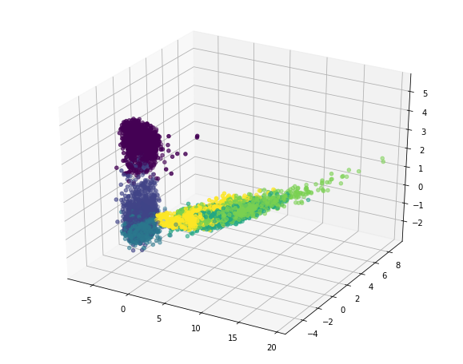

```python
from mpl_toolkits.mplot3d import Axes3D
fig = plt.figure(figsize = (10, 8))
ax = fig.add_subplot(111, projection = '3d')
x_ax = np.array(p3_train[:, 0]).flatten()
y_ax = np.array(p3_train[:, 1]).flatten()
z_ax = np.array(p3_train[:, 2]).flatten()
ax.scatter(x_ax, y_ax, z_ax, c = Y_train, marker = 'o')
plt.show()
```

- Here, the datapoints seem to take on a set of forms that correspond to the 6 classes of human activity.
- The left and right seem to contain two large classes of activity, with 3 subsets contained within each of these sets.
- The group on the left is comprised of: LAYING, STANDING, and SITTING - and the other group: WALKING, WALKING UPSTAIRS, and WALKING DOWNSTAIRS. Indicating the 2 different characteristics between these types of activities, captured by the accelerometer data.
- Rotating the axes, providing another view of the plotted datapoints:

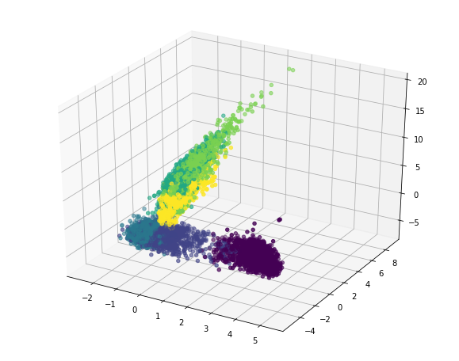

```python
fig = plt.figure(figsize = (10, 8))
ax = fig.add_subplot(111, projection = '3d')
x_ax = np.array(p3_train[:, 2]).flatten()
y_ax = np.array(p3_train[:, 1]).flatten()
z_ax = np.array(p3_train[:, 0]).flatten()
ax.scatter(x_ax, y_ax, z_ax, c = Y_train, marker = 'o')
plt.show()
```

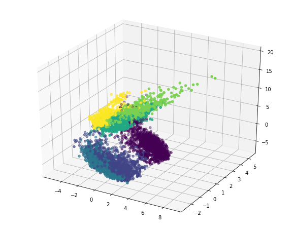

```python
fig = plt.figure(figsize = (10, 8))
ax = fig.add_subplot(111, projection = '3d')
x_ax = np.array(p3_train[:, 1]).flatten()
y_ax = np.array(p3_train[:, 2]).flatten()
z_ax = np.array(p3_train[:, 0]).flatten()
ax.scatter(x_ax, y_ax, z_ax, c = Y_train, marker = 'o')
plt.show()
```

After reducing the original 561 features down to a set of 3 components that capture the majority of the original variance, we can see that there is a definite, discernable difference not only between the 2 major groups of activities (movement and non-movement), but also we can see the differentiation between the separate subgroups within these categories. We have **2 major clusters** of datapoints: **LAYING, STANDING,** and **SITTING** comprising one cluster - and the other cluster being: **WALKING, WALKING UPSTAIRS,** and **WALKING DOWNSTAIRS.**

We can clearly see the 2 major clusters expressing themselves in the first two scatterplots, and after rotating the view of the datapoints in the 3rd scatterplot above, the subgroups become much more visible.

Initial fitting of a random forest classifier:

```python
rf_classifier = RandomForestClassifier(n_estimators=10,
                                       criterion='gini',
                                       max_depth=None,
                                       min_samples_split=2,
                                       min_samples_leaf=1,
                                       min_weight_fraction_leaf=0.0,
                                       max_features='auto',
                                       max_leaf_nodes=None,
                                       min_impurity_decrease=0.0,
                                       min_impurity_split=None,
                                       bootstrap=True,
                                       oob_score=False,
                                       n_jobs=1,
                                       random_state=123,
                                       verbose=0,
                                       warm_start=False,
                                       class_weight=None)
```

```python
rf_classifier.fit(X_train, Y_train)
y_hat = rf_classifier.predict(X_test)
```

```python
print(accuracy_score(Y_test, y_hat))
print('\n')
print(confusion_matrix(Y_test, y_hat))
print('\n')
print(classification_report(Y_test, y_hat))
```

```
0.909060061079


[[537   0   0   0   0   0]
 [  0 445  45   0   0   1]
 [  0  63 469   0   0   0]
 [  0   0   0 477  12   7]
 [  0   0   0  27 354  39]
 [  0   0   0  61  13 397]]


             precision    recall  f1-score   support

          0       1.00      1.00      1.00       537
          1       0.88      0.91      0.89       491
          2       0.91      0.88      0.90       532
          3       0.84      0.96      0.90       496
          4       0.93      0.84      0.89       420
          5       0.89      0.84      0.87       471

avg / total       0.91      0.91      0.91      2947
```

Our first run with the random forest classifier has produced an accuracy score of 0.90906, with similar values for the recall and precision. We will seek to improve on the model's performance by adjusting the parameters.

### Run 1: Use the criterion of the Gini index, using the measure of impurity:

- Run a series of trees, from 3 to 70:

```python
list_accuracy1 = []
list_confusion1 = {}

for i in range(3, 71):
    rf_classifier_gini = RandomForestClassifier(n_estimators=i,
                                                criterion='gini',
                                                max_depth=None,
                                                min_samples_split=2,
                                                min_samples_leaf=1,
                                                min_weight_fraction_leaf=0.0,
                                                max_features='auto',
                                                max_leaf_nodes=None,
                                                min_impurity_decrease=0.0,
                                                min_impurity_split=None,
                                                bootstrap=True,
                                                oob_score=False,
                                                n_jobs=1,
                                                random_state=123,
                                                verbose=0,
                                                warm_start=False,
                                                class_weight=None)
    rf_classifier_gini.fit(X_train, Y_train)
    y_hat = rf_classifier_gini.predict(X_test)
    list_accuracy1.append(accuracy_score(Y_test, y_hat))
    list_confusion1[i] = confusion_matrix(Y_test, y_hat)
```

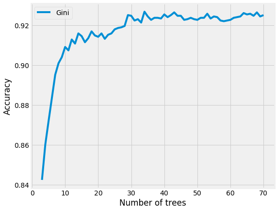

```python
plt.figure(figsize=(9, 7))
plt.style.use('fivethirtyeight')
x_units = list(range(3, 71))
plt.plot(x_units, list_accuracy1, label='Gini')
#plt.axis([0.5, 9.5, 0.95, 1.0])
plt.xlabel('Number of trees')
plt.ylabel('Accuracy')
plt.legend()
plt.show()
```

```python
max(list_accuracy1)
```

```
0.92670512385476755
```

```python
print(list_confusion1[34])
```

```
[[537   0   0   0   0   0]
 [  0 440  51   0   0   0]
 [  0  45 487   0   0   0]
 [  0   0   0 480  10   6]
 [  0   0   0  17 364  39]
 [  0   0   0  42   6 423]]
```

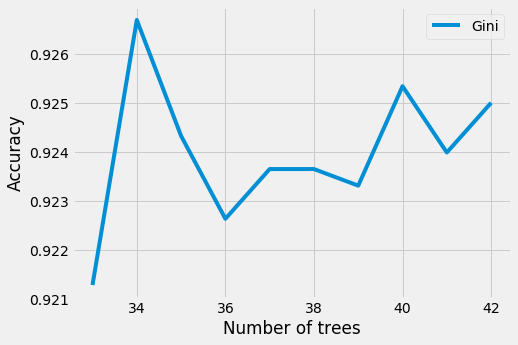

```python
plt.figure(figsize=(7, 5))
plt.style.use('fivethirtyeight')
plt.plot(x_units[30:40], list_accuracy1[30:40], label='Gini')
plt.xlabel('Number of trees')
plt.ylabel('Accuracy')
plt.legend()
plt.show()
```

Using the Gini index as our criterion for impurity, our accuracy score peaks at 34 decision trees with our random forest. There is a rapid rise in accuracy as the number of trees rises from 3 to 10, then the rate of increase reduces slightly. After about 40 trees, there is a point of diminishing returns with our model, as the performance gains are minimal while the computational expense increases.

Looking at the confusion matrix, we see that **walking downstairs** and especially **walking upstairs** are being misclassified as **walking**, and the **walking downstairs** is also being misclassified as **walking upstairs**.

### Run 2: adjust the criterion from Gini to Entropy, measuring the amount of information gain:

```python
list_accuracy2 = []
list_confusion2 = {}

for i in range(3, 71):
    rf_classifier_entr = RandomForestClassifier(n_estimators=i,
                                                criterion='entropy',
                                                max_depth=None,
                                                min_samples_split=2,
                                                min_samples_leaf=1,
                                                min_weight_fraction_leaf=0.0,
                                                max_features='auto',
                                                max_leaf_nodes=None,
                                                min_impurity_decrease=0.0,
                                                min_impurity_split=None,
                                                bootstrap=True,
                                                oob_score=False,
                                                n_jobs=1,
                                                random_state=123,
                                                verbose=0,
                                                warm_start=False,
                                                class_weight=None)
    rf_classifier_entr.fit(X_train, Y_train)
    y_hat = rf_classifier_entr.predict(X_test)
    list_accuracy2.append(accuracy_score(Y_test, y_hat))
    list_confusion2[i] = confusion_matrix(Y_test, y_hat)
```

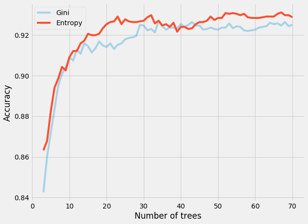

```python
plt.figure(figsize=(9, 7))
plt.style.use('fivethirtyeight')
plt.plot(x_units, list_accuracy1, label='Gini', alpha=0.3)
plt.plot(x_units, list_accuracy2, label='Entropy')
#plt.axis([0.5, 9.5, 0.95, 1.0])
plt.xlabel('Number of trees')
plt.ylabel('Accuracy')
plt.legend()
plt.show()
```

```python
max(list_accuracy2)
```

```
0.93111638954869358
```

```python
print(list_confusion2[32])
```

```
[[537   0   0   0   0   0]
 [  0 440  51   0   0   0]
 [  0  40 492   0   0   0]
 [  0   0   0 484   3   9]
 [  0   0   0  20 355  45]
 [  0   0   0  31   8 432]]
```

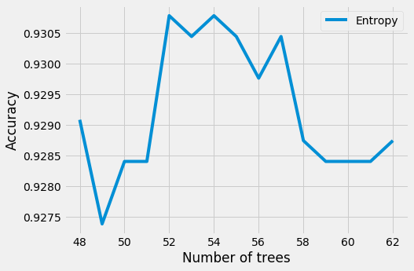

```python
plt.figure(figsize=(7, 5))
plt.style.use('fivethirtyeight')
plt.plot(x_units[45:60], list_accuracy2[45:60], label='Entropy')
plt.xlabel('Number of trees')
plt.ylabel('Accuracy')
plt.legend()
plt.show()
```

Looking at the confusion matrix, again we see that **walking downstairs** and especially **walking upstairs** are being misclassified as **walking**, and the **walking downstairs** is also being misclassified as **walking upstairs**.

### Run 3: adjust the max features to consider when looking for the best split to log<sub>2</sub>(n_features):

```python
list_accuracy3 = []
list_confusion3 = {}

for i in range(3, 71):
    rf_classifier_log2 = RandomForestClassifier(n_estimators=i,
                                                criterion='entropy',
                                                max_depth=None,
                                                min_samples_split=2,
                                                min_samples_leaf=1,
                                                min_weight_fraction_leaf=0.0,
                                                max_features='log2',
                                                max_leaf_nodes=None,
                                                min_impurity_decrease=0.0,
                                                min_impurity_split=None,
                                                bootstrap=True,
                                                oob_score=False,
                                                n_jobs=1,
                                                random_state=123,
                                                verbose=0,
                                                warm_start=False,
                                                class_weight=None)
    rf_classifier_log2.fit(X_train, Y_train)
    y_hat = rf_classifier_log2.predict(X_test)
    list_accuracy3.append(accuracy_score(Y_test, y_hat))
    list_confusion3[i] = confusion_matrix(Y_test, y_hat)
```

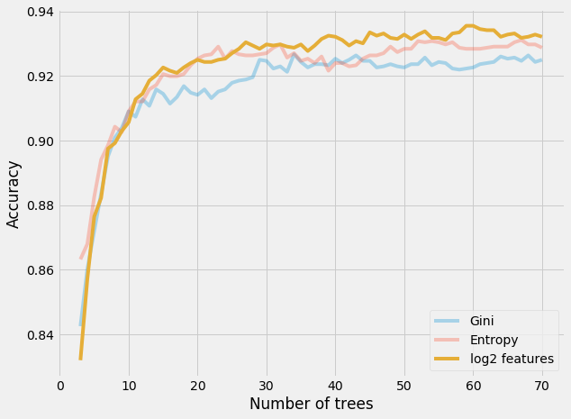

```python
plt.figure(figsize=(9, 7))
plt.style.use('fivethirtyeight')
plt.plot(x_units, list_accuracy1, label='Gini', alpha=0.3)
plt.plot(x_units, list_accuracy2, label='Entropy', alpha=0.3)
plt.plot(x_units, list_accuracy3, label='log2 features')
plt.xlabel('Number of trees')
plt.ylabel('Accuracy')
plt.legend()
plt.show()
```

```python
max(list_accuracy3)
```

```
0.9355276552426196
```

```python
print(list_confusion3[59])
```

```
[[537   0   0   0   0   0]
 [  0 430  61   0   0   0]
 [  0  13 519   0   0   0]
 [  0   0   0 483   8   5]
 [  0   0   0  19 355  46]
 [  0   0   0  31   7 433]]
```

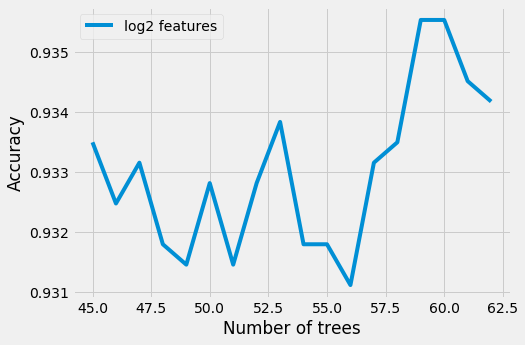

```python
plt.figure(figsize=(7, 5))
plt.style.use('fivethirtyeight')
plt.plot(x_units[42:60], list_accuracy3[42:60], label='log2 features')
plt.xlabel('Number of trees')
plt.ylabel('Accuracy')
plt.legend()
plt.show()
```

With the maximum number of features to be considered at each split is set to log<sub>2</sub>(n_features), our accuracy score peaks at 59 decision trees with our random forest. We are now seeing the repetition of a logarithmic curve with the overall rate of growth on all of our accuracy tests. There is a rapid rise in accuracy as the number of trees rises from 3 to 10, then the rate of increase again reduces slightly. The accuracy seems to keep rising, although very slowly up to 70 trees.

Looking at the confusion matrix, again we see that **walking downstairs**, **walking upstairs**, and **walking**, are still being misclassified as previously.

### Run 4: adjust the maximum depth of the tree, with a range from 1 to 40:

```python
list_accuracy4 = []
list_confusion4 = {}
max_depth = list(range(1, 41))
for i in max_depth:
    rf_classifier_half = RandomForestClassifier(n_estimators=59,
                                                criterion='entropy',
                                                max_depth=i,
                                                min_samples_split=2,
                                                min_samples_leaf=1,
                                                min_weight_fraction_leaf=0.0,
                                                max_features='log2',
                                                max_leaf_nodes=None,
                                                min_impurity_decrease=0.0,
                                                min_impurity_split=None,
                                                bootstrap=True,
                                                oob_score=False,
                                                n_jobs=1,
                                                random_state=123,
                                                verbose=0,
                                                warm_start=False,
                                                class_weight=None)
    rf_classifier_half.fit(X_train, Y_train)
    y_hat = rf_classifier_half.predict(X_test)
    list_accuracy4.append(accuracy_score(Y_test, y_hat))
    list_confusion4[i] = confusion_matrix(Y_test, y_hat)
```

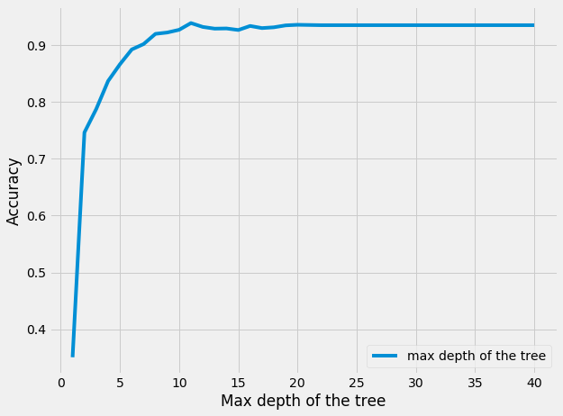

```python
plt.figure(figsize=(9, 7))
plt.style.use('fivethirtyeight')
plt.plot(max_depth, list_accuracy4, label='max depth of the tree')
plt.xlabel('Max depth of the tree')
plt.ylabel('Accuracy')
plt.legend()
plt.show()
```

```python
list_accuracy4[19]
```

```
0.93620631150322364
```

```python
print(list_confusion4[19])
```

```
[[537   0   0   0   0   0]
 [  1 429  61   0   0   0]
 [  0  13 519   0   0   0]
 [  0   0   0 485   6   5]
 [  0   0   0  20 358  42]
 [  0   0   0  36   7 428]]
```

As we increase the maximum depth of the tree, we see a large performance increase that slows down by about a depth of 5, and peaking at a maximum depth of 11, and leveling off at around 20. At a maximum depth of 20, we see an accuracy of **0.93621**, slightly exceeding our previous high of **0.93553** with an automatic depth setting above with model 3.

### Run 5: adjust the minimum impurity decrease to split nodes:

The weighted impurity decrease is defined as the following:

```
samples current node / total samples * (impurity - samples right child / total samples * right_impurity
                                                  - samples left child / total samples * left_impurity)
```

We will incrementally increase this threshold from the default of 0.0 to 0.1. Each node will be split if this split induces a decrease of the impurity greater than or equal to this value:

```python
list_accuracy5 = []
list_confusion5 = {}
min_impurity_dec = [0.0, 0.005, 0.01, 0.015, 0.02, 0.025, 0.03, 0.035, 0.04, 0.045, 0.05, 0.055, 0.06, 0.065, 0.07, 0.075, 0.08, 0.085, 0.09, 0.095]

for i in min_impurity_dec:
    rf_classifier_impu = RandomForestClassifier(n_estimators=59,
                                                criterion='entropy',
                                                max_depth=20,
                                                min_samples_split=2,
                                                min_samples_leaf=1,
                                                min_weight_fraction_leaf=0.0,
                                                max_features='log2',
                                                max_leaf_nodes=None,
                                                min_impurity_decrease=i,
                                                min_impurity_split=None,
                                                bootstrap=True,
                                                oob_score=False,
                                                n_jobs=1,
                                                random_state=123,
                                                verbose=0,
                                                warm_start=False,
                                                class_weight=None)
    rf_classifier_impu.fit(X_train, Y_train)
    y_hat = rf_classifier_impu.predict(X_test)
    list_accuracy5.append(accuracy_score(Y_test, y_hat))
    list_confusion5[i] = confusion_matrix(Y_test, y_hat)
```

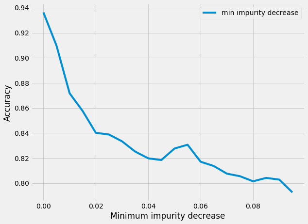

```python
plt.figure(figsize=(9, 7))
plt.plot(min_impurity_dec, list_accuracy5, label='min impurity decrease')
plt.xlabel('Minimum impurity decrease')
plt.ylabel('Accuracy')
plt.legend()
plt.show()
```

```python
max(list_accuracy5)
```

```
0.93620631150322364
```

Increasing the impurity threshold for each node at the split is obviously not the correct direction to persue, as the accuracy scores trend downward rapidly as the threshold increases even slightly from 0. A two-hundredths of a point increase has had a tremendously detrimental effect on the model.

### Results and Findings

With a relatively large number of decision trees in our random forest (**59**) we have been able to achieve **0.93621** accuracy. This may have been a byproduct of our dataset, with its **561 features**, and would require a relatively large number of randomly sampled subsets of these features to create a more accurate consensus output classification. Measuring the information gain as we traverse down the trees with **entropy**, has also yielded better performance with this dataset.

There is a definite discernable difficulty in classifying the difference between walking downstairs, walking upstairs, and walking regularly. The observed activities of **walking downstairs** and especially **walking upstairs** are being misclassified as **walking**, and the **walking downstairs** is also being misclassified as **walking upstairs**. Even so, the rest of the human activities are able to be relatively easily classified with a high measure of accuracy.

**Our model has the following hyperparameter settings:**

- **number of trees: 59**
- criterion: Entropy
- maximum depth of 20
- minimum samples per split: 2
- minimum samples per leaf: 1
- max no. of features considered when looking for best split: log<sub>2</sub>(n_features)
- no maximum limit on leaf nodes
- minimum impurity decrease: 0.0
- bootstrap: True (bootstrap aggregation is part of our random forest algo)
- oob score: False (no out of bag samples used when estimating accuracy)
- random state: 123 (allows us to replicate the random initial state)

**The labels are encoded as:**

- 0 laying
- 1 sitting
- 2 standing
- 3 walking
- 4 walking downstairs
- 5 walking upstairs

**Projecting the variance onto 2 principal components and viewing the 6 labels:**

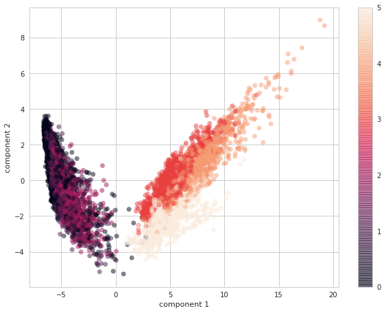

```python
pca_2 = PCA(n_components=2, random_state=123)
pca_2.fit(X_train)
p2 = pca_2.transform(X_train)
sns.set(style='whitegrid')
plt.figure(figsize=(9, 7))
plt.scatter(p2[:, 0], p2[:, 1], c=Y_train, edgecolor='none', alpha=0.5,)
plt.xlabel('component 1')
plt.ylabel('component 2')
plt.colorbar();
```